# Exploratory Data Analysis of Deforestration Dataset

Lohit Marla

2023-10-16

## Dataset: Deforestation

We look at an interesting dataset to investigate factors contributing to deforestation in Western China. Agricultural populations whose livelihood heavily depends on natural resources such as timber production may be affected by deforestation which results from the increasing demand for timber. The deforestation data was collected from four mountainous provinces in Western China (@deng2011pressure). The data file *deforest.csv* has observations from $405$ counties. The variable **fcover** is the observed forest cover divided by 1000. There are $p=17$ predictors:

total population per square km (**tpop**) agricultural population per square km (**apop**) per capita primary industry added value 10,000 yuan (**gdp1**) per capita secondary industry added value 10,000 yuan (**gdp2**) per capita third industry added value 10,000 yuan (**gdp3**) distance to provincial capital (**distpvc**) distance to port or open city (**distport**) length of highway (**hwaylen**) length of natural expressway (**explen**) proportion of plain area (**plain**) average elevation (**elev**) average precipitation for many years (**prec**) average slope in degrees (**slope**) average temperature in degrees Celsius (**temp**) accumulated temperature greater than 0 degrees Celsius (**temp0**) total land area (**area**) an indicator for important reforestation policies (**policy**).

```r
# Load necessary libraries and read the dataset
library(tidyverse)
data1 <- read.csv("Data/deforest.csv", header = TRUE)
data2 <- data1
str(data1)
```

```
## 'data.frame':    405 obs. of  21 variables:
##  $ id      : int  1 2 3 4 5 6 7 8 9 10 ...
##  $ code    : int  360121 360122 360123 360124 360222 360281 360321 360421 360423 360424 ...
##  $ ename   : chr  "nanchangxian" "xinjian" "anyi" "jinxian" ...
##  $ fcover  : num  3.1 39.3 23.7 38.7 265.3 ...
##  $ tpop    : int  93 67 26 77 27 82 25 34 37 81 ...
##  $ apop    : int  74 59 19 65 23 66 22 28 30 68 ...
##  $ gdp1    : num  2820 2819 2101 2387 2199 ...
##  $ gdp2    : num  9744 6301 3968 6314 3454 ...
##  $ gdp3    : num  3898 5167 4868 3502 2633 ...
##  $ distpvc : num  21261 33245 37651 46479 168570 ...
##  $ distport: num  435763 453378 489739 407609 366528 ...
##  $ hwaylen : num  28750 13619 26491 54050 129788 ...
##  $ explen  : num  21420 2173 8122 16306 11674 ...
##  $ plain   : num  0.9222 0.6664 0.3792 0.5128 0.0878 ...
##  $ elev    : int  19 30 70 28 190 76 415 63 334 377 ...
##  $ prec    : int  1569 1521 1571 1619 1758 1758 1597 1560 1505 1591 ...
##  $ slope   : num  0.07 0.33 1.49 0.28 2.91 1.17 4.05 1.14 4.78 4.59 ...
##  $ temp    : num  17.5 17.2 16.8 17.5 16 17.2 15.8 16.7 15.1 15 ...
##  $ temp0   : num  6384 6290 6136 6424 5857 ...
##  $ area    : int  188635 234934 65605 194959 329200 197469 106237 90523 367767 433093 ...
##  $ policy  : int  0 1 0 1 0 0 0 0 1 1 ...
```

### Data Distribution and Normality

Before proceeding with the multiple linear regression analysis, it is imperative to validate the assumptions of normality and homoscedasticity for the response variable

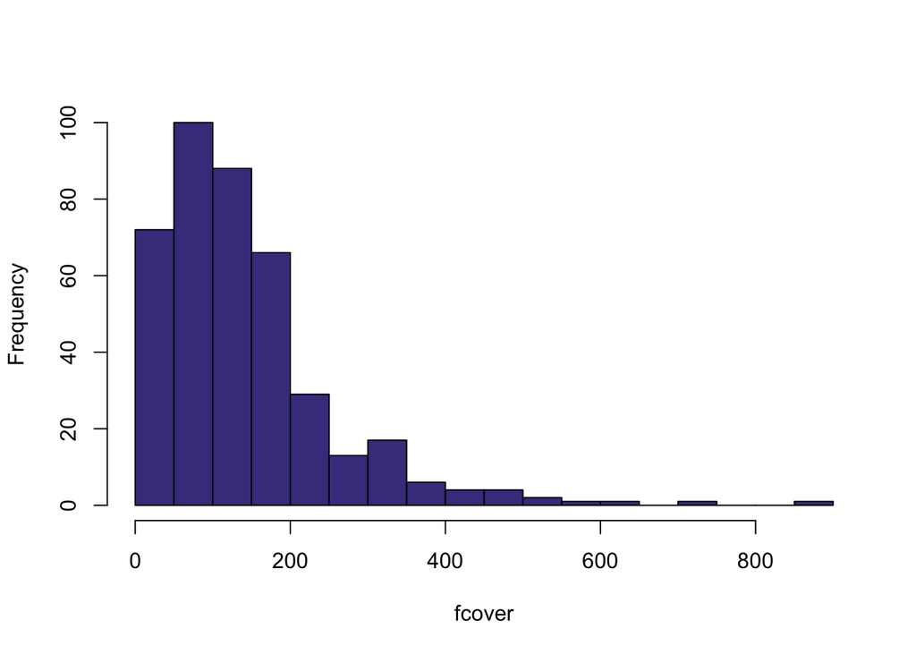

```r
# Check normality and variance assumptions on the response variable
library(e1071)
hist(data1$fcover, breaks = 30, main = "", xlab = "fcover", col = "darkslateblue")
```

```r
shapiro.test(data1$fcover)
```

```
##
##  Shapiro-Wilk normality test
##
## data:  data1$fcover
## W = 0.84914, p-value < 2.2e-16
```

```r
skewness(data1$fcover)
```

```
## [1] 1.977274
```

We can observe that the data is **not satisfying the normality with the fcover** data as the data is right skewed which was confirmed statistically through the shapiro-wilk test - pvalue(which is less than the significance level).

I have applied log transformation to the fcover variable to check for the normality assumption

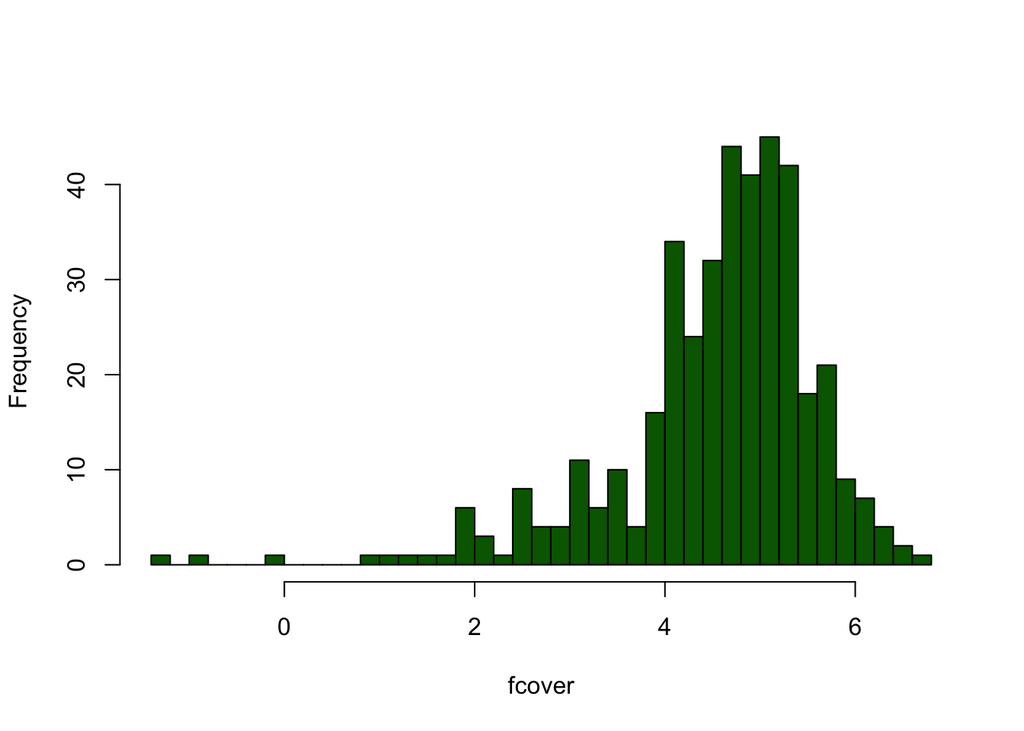

```r
# Apply a log transformation to check the normality assumption
hist(log(data1$fcover), breaks = 30, main = "", xlab = "fcover", col = "darkgreen")
```

```r
shapiro.test(log(data1$fcover))
```

```
##
##  Shapiro-Wilk normality test
##
## data:  log(data1$fcover)
## W = 0.89572, p-value = 5.311e-16
```

```r
skewness(log(data1$fcover))
```

```
## [1] -1.563911
```

```r
# Fit a multiple linear regression model on the log-transformed response variable
data1$logfcover <- log(data1$fcover)
set.seed(87654)
train.prop <- 0.80
trnset <- sort(sample(1:nrow(data1), ceiling(nrow(data1) * train.prop)))
train.set <- data1[trnset, ]
test.set <- data1[-trnset, ]
library(caret)
contpredcols <- 5:20
normParam <- preProcess(train.set[, contpredcols], method = c("center", "scale"))
data.train <- cbind(train.set[, c("logfcover", "policy")], predict(normParam, train.set[, contpredcols]))
data.test <- cbind(test.set[, c("logfcover", "policy")], predict(normParam, test.set[, 5:20]))
mod.log <- lm(logfcover ~ ., data = data.train)
summary(mod.log)
```

```
##
## Call:
## lm(formula = logfcover ~ ., data = data.train)
##
## Residuals:
##      Min       1Q   Median       3Q      Max
## -2.53762 -0.27936  0.07262  0.36022  1.24238
##
## Coefficients:
##              Estimate Std. Error t value Pr(>|t|)
## (Intercept)  4.445392   0.055761  79.722  < 2e-16 ***
## policy       0.101974   0.074142   1.375  0.17002
## tpop         0.265778   0.171795   1.547  0.12288
## apop        -0.269560   0.168553  -1.599  0.11079
## gdp1         0.063386   0.036797   1.723  0.08597 .
## gdp2        -0.165013   0.037840  -4.361 1.77e-05 ***
## gdp3        -0.033722   0.032735  -1.030  0.30376
## distpvc      0.205538   0.098959   2.077  0.03864 *
## distport    -0.627542   0.058441 -10.738  < 2e-16 ***
## hwaylen     -0.207397   0.098895  -2.097  0.03680 *
## explen      -0.004414   0.034629  -0.127  0.89866
## plain       -0.115945   0.040826  -2.840  0.00481 **
## elev         0.138862   0.096908   1.433  0.15290
## prec         0.126751   0.061440   2.063  0.03996 *
## slope        0.592272   0.057393  10.320  < 2e-16 ***
## temp         1.390057   0.447798   3.104  0.00209 **
## temp0       -1.254409   0.440308  -2.849  0.00468 **
## area         0.711989   0.056768  12.542  < 2e-16 ***
## ---
## Signif. codes:  0 '***' 0.001 '**' 0.01 '*' 0.05 '.' 0.1 ' ' 1
##
## Residual standard error: 0.5552 on 306 degrees of freedom
## Multiple R-squared:  0.7595, Adjusted R-squared:  0.7462
## F-statistic: 56.85 on 17 and 306 DF,  p-value: < 2.2e-16
```

The highly significant p-values provide evidence of a strong relationship between the response variable and the explanatory variables. Furthermore, the multiple R-squared value suggests that approximately 75% of the variability in the response variable can be accounted for by the predictor variables. Additionally, the regression coefficients for each variable reveal the nature of their correlation: a negative sign indicates a negative correlation, while a positive sign indicates a positive correlation.

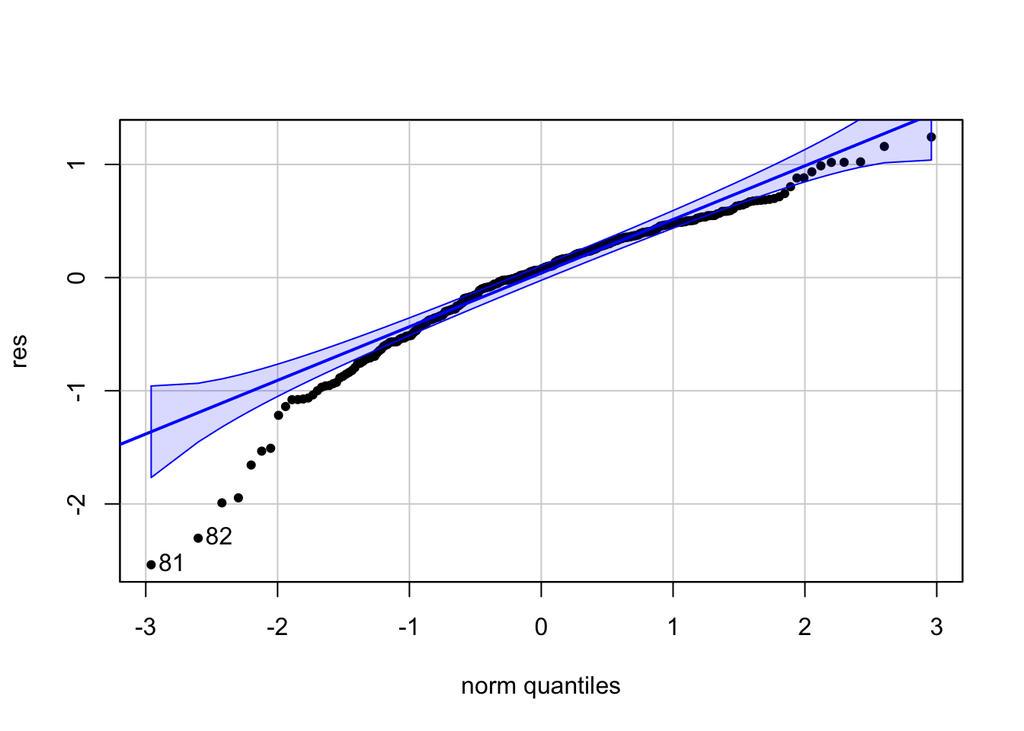

```
## 81 82
## 64 65
```

```r
# Check the normality of residuals from the log-transformed model
res <- residuals(mod.log)
car::qqPlot(res, main = NA, pch = 19, col = "black", cex = 0.7)
```

```r
skew <- skewness(res)
cat("skewness of the residuals -> ", skew)
```

```
## skewness of the residuals ->  -1.170133
```

```r
shapiro.test(res)
```

```
##
##  Shapiro-Wilk normality test
##
## data:  res
## W = 0.93471, p-value = 9.862e-11
```

Upon examining the normal quantile-quantile (q-q) plot of the residuals from the log-transformed model, it is apparent that there is a substantial deviation from the median, indicating a lack of homoscedasticity. Additionally, when inspecting the plot of predicted values from the fitted model, it becomes evident that the predicted data does not follow a normal distribution.

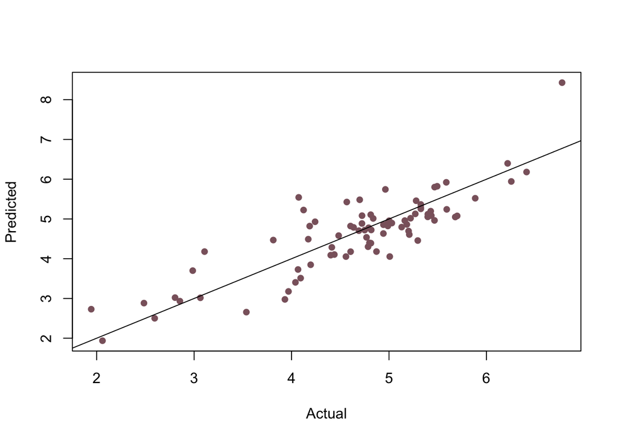

```r
# Plot actual vs. predicted values from the log-transformed model
plot(data.test$logfcover, predict(mod.log, newdata = data.test), col = "pink4", cex = 1.3, xlab = "Actual", ylab = "Predicted", pch= 20)
abline(0, 1)
```

The next step involves applying a square root transformation to the data to assess whether it aligns with the normality assumption.

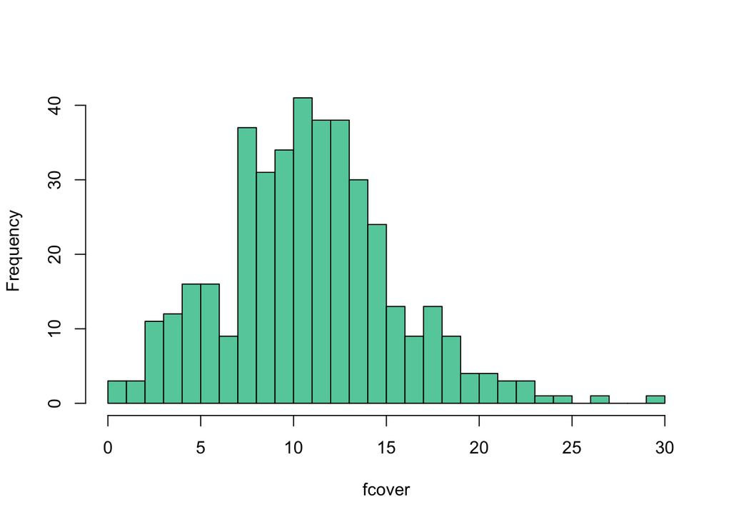

```r
# Apply a square root transformation to check the normality assumption
hist(sqrt(data1$fcover), breaks = 30, main = "", xlab = "fcover", col = "aquamarine3")
```

```r
shapiro.test(sqrt(data1$fcover))
```

```
##
##  Shapiro-Wilk normality test
##
## data:  sqrt(data1$fcover)
## W = 0.98549, p-value = 0.0004441
```

```r
skewness(sqrt(data1$fcover))
```

```
## [1] 0.4269692
```

As depicted by the bar graph, it is evident that the data does not exhibit a normal distribution. This observation is further supported by the results of the Shapiro-Wilk test, which rejects the null hypothesis of normality.

Subsequently, the analysis proceeds with fitting a multiple linear regression model using the square root of the “fcover” variable as the response variable.

```r
# Fit a multiple linear regression model on the square root-transformed response variable
data1$sqrtfcover <- sqrt(data1$fcover)
set.seed(87654)
train.prop <- 0.80
trnset <- sort(sample(1:nrow(data1), ceiling(nrow(data1) * train.prop)))
train.set <- data1[trnset, ]
test.set <- data1[-trnset, ]
library(caret)
contpredcols <- 5:20
normParam <- preProcess(train.set[, contpredcols], method = c("center", "scale"))
data.train <- cbind(train.set[, c("sqrtfcover", "policy")], predict(normParam, train.set[, contpredcols]))
data.test <- cbind(test.set[, c("sqrtfcover", "policy")], predict(normParam, test.set[, 5:20]))
mod.1 <- lm(sqrtfcover ~ ., data = data.train)
summary(mod.1)
```

```
##
## Call:
## lm(formula = sqrtfcover ~ ., data = data.train)
##
## Residuals:
##      Min       1Q   Median       3Q      Max
## -13.0552  -0.9891   0.0826   1.1550   5.2465
##
## Coefficients:
##               Estimate Std. Error t value Pr(>|t|)
## (Intercept)  10.868968   0.196141  55.414  < 2e-16 ***
## policy       -0.223861   0.260796  -0.858 0.391357
## tpop          0.826608   0.604295   1.368 0.172351
## apop         -1.123415   0.592889  -1.895 0.059059 .
## gdp1         -0.004888   0.129433  -0.038 0.969899
## gdp2         -0.069523   0.133105  -0.522 0.601825
## gdp3         -0.081145   0.115147  -0.705 0.481529
## distpvc       0.302879   0.348092   0.870 0.384922
## distport     -1.637127   0.205567  -7.964 3.30e-14 ***
## hwaylen      -0.385816   0.347867  -1.109 0.268262
## explen       -0.013008   0.121810  -0.107 0.915025
## plain        -0.538631   0.143607  -3.751 0.000211 ***
## elev          0.013479   0.340877   0.040 0.968484
## prec          0.451529   0.216116   2.089 0.037507 *
## slope         2.146671   0.201883  10.633  < 2e-16 ***
## temp         11.642760   1.575142   7.392 1.40e-12 ***
## temp0       -10.355381   1.548797  -6.686 1.09e-10 ***
## area          4.243368   0.199684  21.250  < 2e-16 ***
## ---
## Signif. codes:  0 '***' 0.001 '**' 0.01 '*' 0.05 '.' 0.1 ' ' 1
##
## Residual standard error: 1.953 on 306 degrees of freedom
## Multiple R-squared:  0.8241, Adjusted R-squared:  0.8143
## F-statistic: 84.32 on 17 and 306 DF,  p-value: < 2.2e-16
```

The remarkably small p-values provide strong evidence of a significant relationship between the response variable and the explanatory variables. Furthermore, the multiple R-squared value indicates that approximately 82.41% of the variation in the response variable can be attributed to the predictor variables. Additionally, examining the regression coefficients for each variable reveals the nature of their correlation: a negative sign suggests a negative correlation, while a positive sign implies a positive correlation.

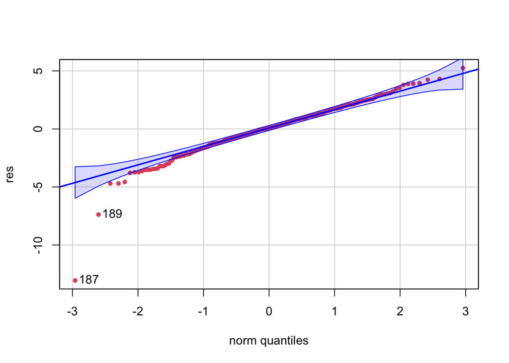

```
## 187 189
## 150 151
```

```r
# Check the normality of residuals from the square root-transformed model
res <- residuals(mod.1)
car::qqPlot(res, main = NA, pch = 19, col = 2, cex = 0.7)
```

```r
skew <- skewness(res)
cat("skewness of the residuals -> ", skew)
```

```
## skewness of the residuals ->  -1.18869
```

```r
shapiro.test(res)
```

```
##
##  Shapiro-Wilk normality test
##
## data:  res
## W = 0.94039, p-value = 3.899e-10
```

Conversely, when reviewing the plot of predicted values from the model, it becomes evident that the predicted values conform to a normal distribution.

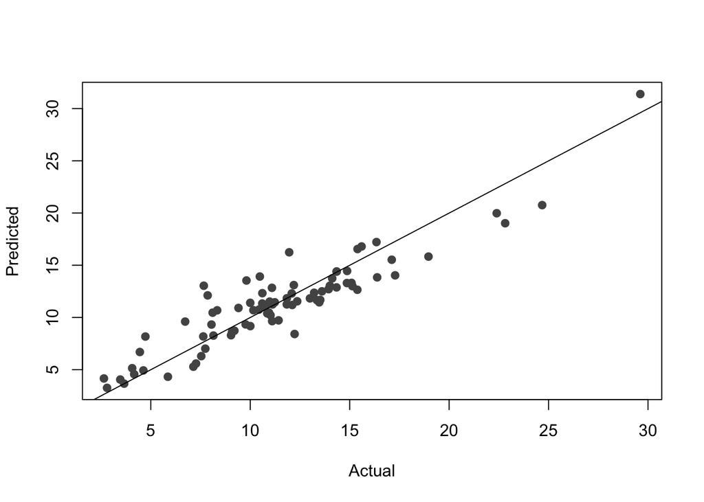

```r
# Plot actual vs. predicted values from the square root-transformed model
plot(data.test$sqrtfcover, predict(mod.1, newdata = data.test), col = "grey33", cex = 1.5, pch= 20, xlab = "Actual", ylab = "Predicted")
abline(0, 1)
```

Comparing the two models, it is evident that the normality assumption was not met for both the log-transformed and square root-transformed data, despite identical p-values. However, the square root transformation exhibits a better goodness of fit, explaining approximately 82.4% of the variance in the response variable, in contrast to the 74.62% explained by the log transformation. It’s important to note that a higher R-squared value does not necessarily indicate a better model, as it may lead to overfitting. Thus, it is crucial to investigate other factors such as collinearity, outliers, leverage points, and conduct further diagnostics on the residuals. Notably, the predicted values for the square root-transformed data closely adhere to a normal distribution, while the log-transformed data does not exhibit a linear pattern. Additionally, the variance test on the residuals appears to be more favorable for the square root-transformed data when compared to the log-transformed data.

To assess normality, we will employ the Box-Cox transformation. Below is the code for implementing the Box-Cox transformation on the response variable:

```r
# Apply Box-Cox transformation to the response variable
library(MASS)
```

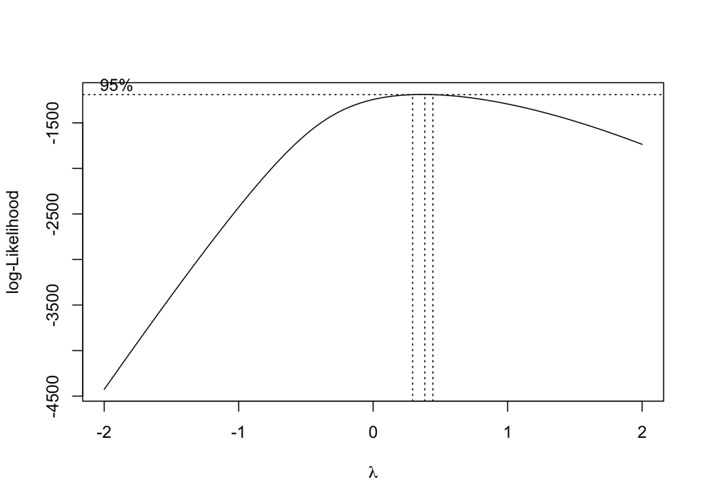

```r
boxcox.out <- boxcox(lm(fcover ~ 1, data = data2))
```

```r
(lambda <- boxcox.out$x[which.max(boxcox.out$y)])
```

```
## [1] 0.3838384
```

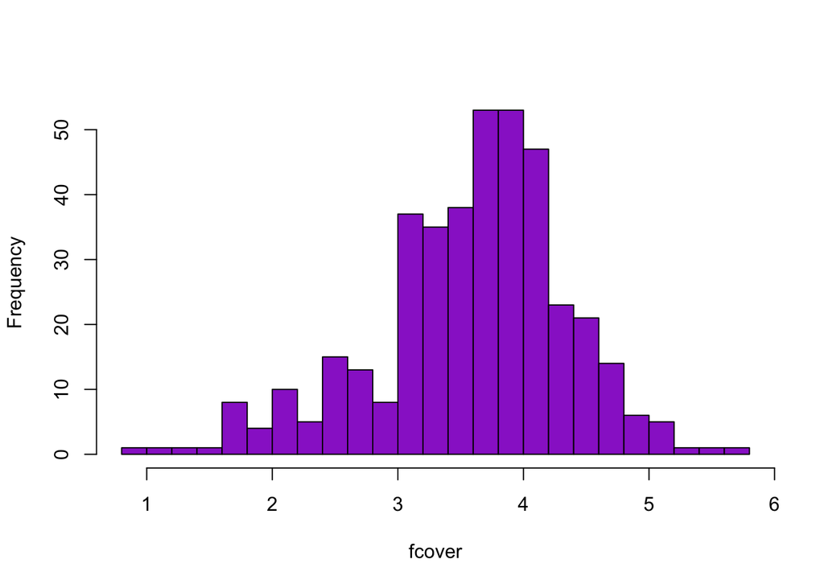

```r
data2$boxcoxfcover <- (data2$fcover^lambda - 1) / lambda
hist(sqrt(data2$boxcoxfcover), breaks = 30, main = "", xlab = "fcover", col = "darkorchid3")
```

```r
shapiro.test(data2$boxcoxfcover)
```

```
##
##  Shapiro-Wilk normality test
##
## data:  data2$boxcoxfcover
## W = 0.99365, p-value = 0.08752
```

```r
skewness(data2$boxcoxfcover)
```

```
## [1] 0.06067338
```

The normality assumption for the response variable is validated through the application of the Box-Cox transformation. This confirmation is supported both visually from the plots and statistically through significant tests.

### Multiple Linear Regression

```r
# Fit a multiple linear regression model on the Box-Cox-transformed response variable
set.seed(87654)
train.prop <- 0.80
trnset <- sort(sample(1:nrow(data2), ceiling(nrow(data2) * train.prop)))
train.set <- data2[trnset, ]
test.set <- data2[-trnset, ]
library(caret)
contpredcols <- 5:20
normParam <- preProcess(train.set[, contpredcols], method = c("center", "scale"))
data.train <- cbind(train.set[, c("boxcoxfcover", "policy")], predict(normParam, train.set[, contpredcols]))
data.test <- cbind(test.set[, c("boxcoxfcover", "policy")], predict(normParam, test.set[, 5:20]))
mod.2 <- lm(boxcoxfcover ~ ., data = data.train)
summary(mod.2)
```

```
##
## Call:
## lm(formula = boxcoxfcover ~ ., data = data.train)
##
## Residuals:
##     Min      1Q  Median      3Q     Max
## -13.901  -1.312   0.198   1.568   6.008
##
## Coefficients:
##               Estimate Std. Error t value Pr(>|t|)
## (Intercept)  13.288493   0.232521  57.150  < 2e-16 ***
## policy       -0.111236   0.309167  -0.360 0.719249
## tpop          1.109306   0.716376   1.548 0.122536
## apop         -1.398046   0.702854  -1.989 0.047581 *
## gdp1          0.060404   0.153440   0.394 0.694100
## gdp2         -0.203812   0.157792  -1.292 0.197453
## gdp3         -0.116596   0.136504  -0.854 0.393684
## distpvc       0.467044   0.412654   1.132 0.258602
## distport     -2.201728   0.243695  -9.035  < 2e-16 ***
## hwaylen      -0.537320   0.412387  -1.303 0.193571
## explen       -0.009173   0.144402  -0.064 0.949392
## plain        -0.647045   0.170242  -3.801 0.000174 ***
## elev          0.138259   0.404100   0.342 0.732480
## prec          0.540895   0.256200   2.111 0.035564 *
## slope         2.639823   0.239327  11.030  < 2e-16 ***
## temp         12.304222   1.867290   6.589 1.93e-10 ***
## temp0       -10.956030   1.836059  -5.967 6.67e-09 ***
## area          4.711518   0.236721  19.903  < 2e-16 ***
## ---
## Signif. codes:  0 '***' 0.001 '**' 0.01 '*' 0.05 '.' 0.1 ' ' 1
##
## Residual standard error: 2.315 on 306 degrees of freedom
## Multiple R-squared:  0.8207, Adjusted R-squared:  0.8107
## F-statistic: 82.38 on 17 and 306 DF,  p-value: < 2.2e-16
```

The output represents the results of a multiple linear regression analysis of the Box-Cox transformed response variable on the predictor variables. Here’s how to interpret the values:

**Coefficients:** These values represent the estimated coefficients for each predictor variable. They indicate the change in the response variable for a one-unit change in the predictor, holding all other predictors constant. The “Estimate” column provides the point estimate for each coefficient.

**Standard Error:** These values measure the variability of the coefficient estimates. Smaller standard errors indicate more precise estimates.

**t-value:** The t-value is a measure of how many standard errors the coefficient estimate is away from zero. Larger absolute t-values suggest stronger evidence that the variable has a significant effect on the response.

**Pr(>|t|):** This column provides the p-value associated with each coefficient. Low p-values (typically less than 0.05) suggest that the predictor variable is statistically significant in predicting the response.

**Residuals:** These statistics describe the distribution of the residuals (model errors) after fitting the regression. The “Min,” “1Q,” “Median,” “3Q,” and “Max” represent minimum, first quartile, median, third quartile, and maximum values of the residuals, respectively.

**Residual standard error:** This is an estimate of the standard deviation of the residuals. It measures the typical magnitude of errors in the model.

**Multiple R-squared:** This value, often denoted as R-squared, represents the proportion of the variance in the response variable that is explained by the predictor variables. In this case, approximately 82.07% of the variation in the transformed response variable is explained by the predictors.

**Adjusted R-squared:** The adjusted R-squared accounts for the number of predictors in the model. It adjusts R-squared for the degrees of freedom, providing a more realistic assessment of model fit. In this case, approximately 81.07% of the variation is explained by the predictors.

**F-statistic:** The F-statistic tests whether there is a significant relationship between the predictor variables and the response. A high F-statistic and a low associated p-value suggest that at least one predictor variable is significantly related to the response.

**Degrees of Freedom (DF):** These values represent the degrees of freedom associated with the F-statistic.

In summary, this output provides information about the statistical significance of each predictor variable, the goodness of fit of the model, and the extent to which the predictors explain the variability in the response variable. It indicates that several predictors are statistically significant, and the model explains a substantial portion of the variance in the transformed response variable.

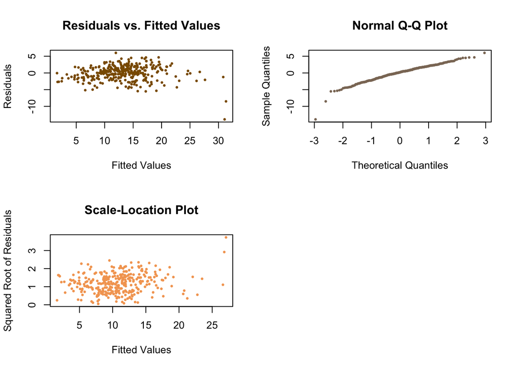

```r
# Set up a 2x2 layout for diagnostic plots
par(mfrow = c(2, 2))

# Customize the appearance of each diagnostic plot with official color names
plot(mod.2$fitted.values, residuals(mod.2),
     col = "orange4", pch = 20, cex = 0.6,
     xlab = "Fitted Values", ylab = "Residuals",
     main = "Residuals vs. Fitted Values")

qqnorm(residuals(mod.2), col = "peachpuff4", pch = 20, cex = 0.6,
       xlab = "Theoretical Quantiles", ylab = "Sample Quantiles",
       main = "Normal Q-Q Plot")

plot(mod.1$fitted.values, sqrt(abs(residuals(mod.2))),
     col = "sandybrown", pch = 20, cex = 0.6,
     xlab = "Fitted Values", ylab = "Squared Root of Residuals",
     main = "Scale-Location Plot")

# Include additional customized plots as needed
```

### Residual Analysis

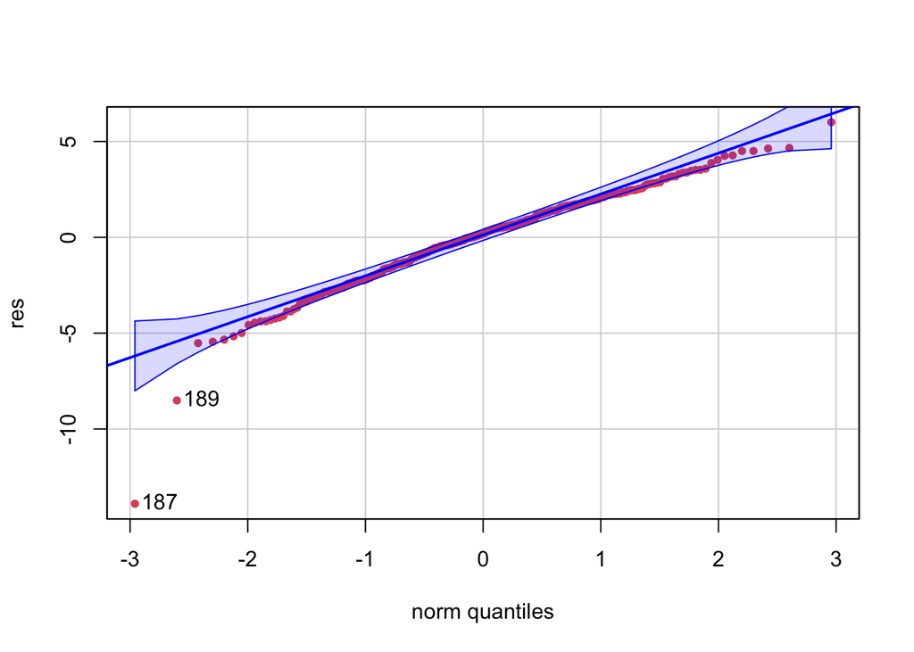

```
## 187 189
## 150 151
```

```r
res <- residuals(mod.2)
car::qqPlot(res, main = NA, pch = 19, col = 2, cex = 0.7)
```

```r
skew <- skewness(res)
cat("Skewness of the residuals: ", skew)
```

```
## Skewness of the residuals:  -1.015308
```

```r
shapiro.test(res)
```

```
##
##  Shapiro-Wilk normality test
##
## data:  res
## W = 0.95455, p-value = 1.796e-08
```

The q-q plot reveals the presence of two outliers. While these outliers may not necessarily have a significant impact on the model, it is important to conduct further checks to assess their influence. One common approach for outlier detection is to examine studentized residuals. Studentized residuals are standardized residuals that account for the estimated error variance and leverage points, making them a useful tool for identifying influential data points.

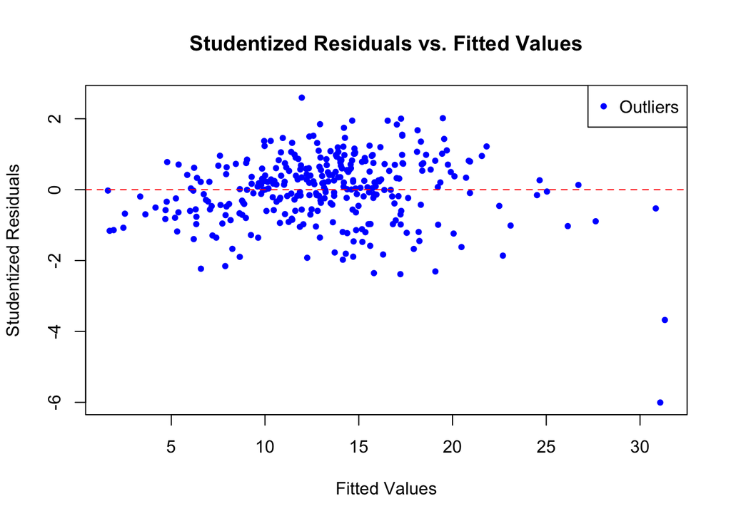

```r
#we need to calcualte the studentised residuals to get the intervals
sigma_residuals <- sigma(mod.2)
studentized_residuals <- res / sigma_residuals

# Create a scatterplot of fitted values vs. studentized residuals
plot(fitted(mod.2), studentized_residuals,
     xlab = "Fitted Values", ylab = "Studentized Residuals",
     main = "Studentized Residuals vs. Fitted Values",
     pch = 20, col = "blue")

# Add a reference line at y = 0 for easier interpretation
abline(h = 0, col = "red", lty = 2)

# Add a legend
legend("topright", legend = "Outliers", col = "blue", pch = 20)
```

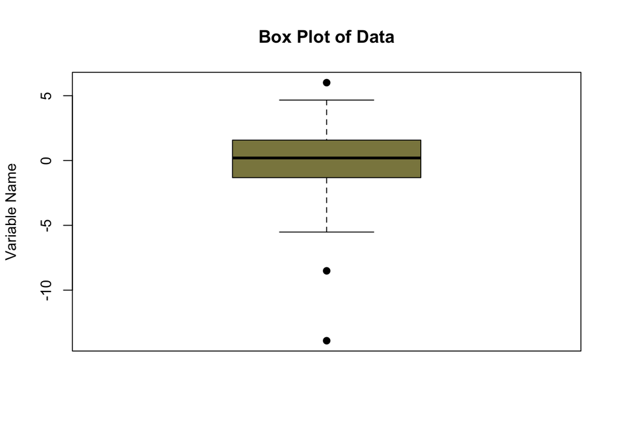

```r
boxplot(res, main = "Box Plot of Data", ylab = "Variable Name", col= "khaki4", pch = 19)
```

```r
extpts <- which(abs(residuals(mod.2)) > 3*sd(residuals(mod.2)))
extpts
```

```
## 187 189
## 150 151
```

Based on the results, it is apparent that the majority of data points cluster around a range near 0, while two data points are positioned well outside the quantile range of -2 to 2. Additionally, these two outliers exhibit standard deviations more than three times greater than the rest of the data. This suggests that these outliers have the potential to exert a disproportionate influence on the model.

A recommended course of action is to remove these outliers from the dataset and proceed with fitting the model, as their presence could potentially lead to misleading model results. Removing outliers can result in a more robust and accurate model.

### Eliminating Outliers

```r
train.set.2 <- data.train[-extpts,]
mod.expts <- lm(boxcoxfcover ~ ., data = train.set.2)
summary(mod.expts)
```

```
##
## Call:
## lm(formula = boxcoxfcover ~ ., data = train.set.2)
##
## Residuals:
##     Min      1Q  Median      3Q     Max
## -6.2080 -1.3051  0.1336  1.4048  4.2757
##
## Coefficients:
##              Estimate Std. Error t value Pr(>|t|)
## (Intercept) 13.330402   0.199284  66.892  < 2e-16 ***
## policy       0.006943   0.265623   0.026    0.979
## tpop         0.577399   0.614768   0.939    0.348
## apop        -1.189042   0.601547  -1.977    0.049 *
## gdp1         0.019443   0.131476   0.148    0.883
## gdp2        -0.177796   0.134999  -1.317    0.189
## gdp3        -0.144598   0.116796  -1.238    0.217
## distpvc      0.042857   0.355958   0.120    0.904
## distport    -1.979922   0.209568  -9.448  < 2e-16 ***
## hwaylen     -0.113134   0.355741  -0.318    0.751
## explen       0.066031   0.124104   0.532    0.595
## plain       -0.637141   0.145619  -4.375 1.67e-05 ***
## elev        -0.283570   0.347984  -0.815    0.416
## prec         0.353206   0.220216   1.604    0.110
## slope        2.328798   0.207023  11.249  < 2e-16 ***
## temp        10.182064   1.630389   6.245 1.42e-09 ***
## temp0       -8.762254   1.606315  -5.455 1.02e-07 ***
## area         5.668501   0.221949  25.540  < 2e-16 ***
## ---
## Signif. codes:  0 '***' 0.001 '**' 0.01 '*' 0.05 '.' 0.1 ' ' 1
##
## Residual standard error: 1.98 on 304 degrees of freedom
## Multiple R-squared:  0.8681, Adjusted R-squared:  0.8607
## F-statistic: 117.7 on 17 and 304 DF,  p-value: < 2.2e-16
```

It’s important to strike a balance between model complexity and goodness of fit. While a higher R-squared value can be desirable, it should not come at the cost of overfitting the model to the training data. To address potential overfitting, you may consider the following approaches:

**Feature Selection:** Review the significance and relevance of each predictor variable. Remove any variables that do not contribute meaningfully to the model.

**Cross-Validation:** Use techniques like cross-validation to assess the model’s performance on unseen data. Cross-validation helps gauge how well the model generalizes to new observations.

**Regularization:** Consider regularization techniques such as Lasso or Ridge regression to penalize the inclusion of too many predictors in the model.

**Collect More Data:** If possible, collect additional data to increase the size of the dataset, which can help reduce overfitting.

**Robust Diagnostic Checks:** Continue to perform thorough diagnostic checks, including examining residual plots, to identify any potential issues or outliers that may still exist in the data.

Balancing model performance and complexity is an essential aspect of building a robust and generalizable regression model.

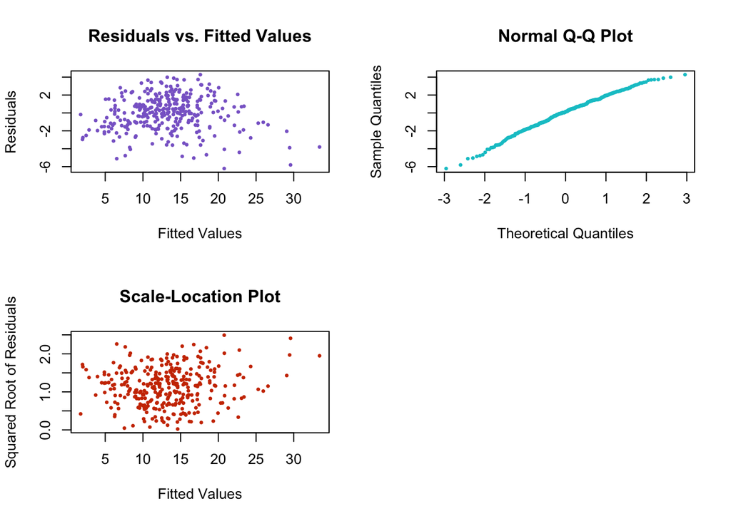

```r
# Set up a 2x2 layout for diagnostic plots
par(mfrow = c(2, 2))

# Customize the appearance of each diagnostic plot with official color names
plot(mod.expts$fitted.values, residuals(mod.expts),
     col = "mediumpurple3", pch = 20, cex = 0.6,
     xlab = "Fitted Values", ylab = "Residuals",
     main = "Residuals vs. Fitted Values")

qqnorm(residuals(mod.expts), col = "turquoise3", pch = 20, cex = 0.6,
       xlab = "Theoretical Quantiles", ylab = "Sample Quantiles",
       main = "Normal Q-Q Plot")

plot(mod.expts$fitted.values, sqrt(abs(residuals(mod.expts))),
     col = "orangered3", pch = 20, cex = 0.6,
     xlab = "Fitted Values", ylab = "Squared Root of Residuals",
     main = "Scale-Location Plot")

# Include additional customized plots as needed
```

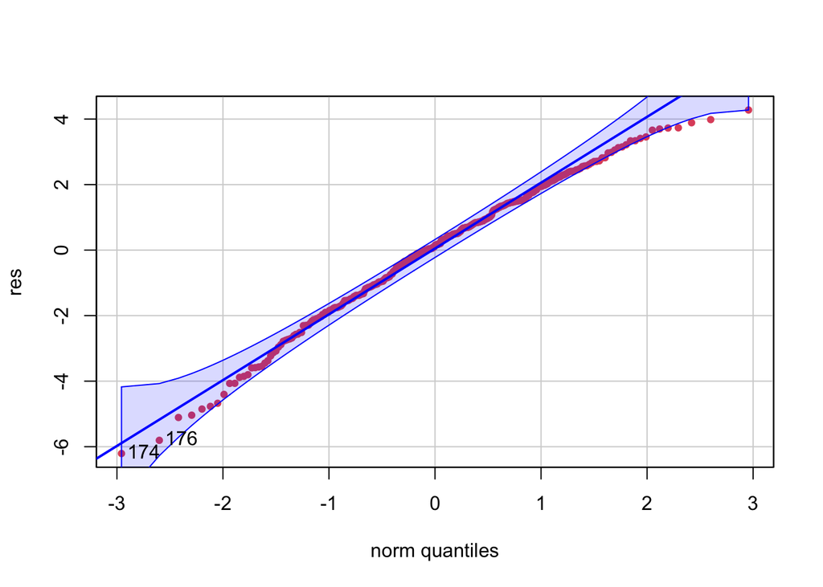

```
## 174 176
## 140 142
```

```r
# Check the normality of residuals from the square root-transformed model
res <- residuals(mod.expts)
car::qqPlot(res, main = NA, pch = 19, col = 2, cex = 0.7)
```

```r
skew <- skewness(res)
cat("skewness of the residuals -> ", skew)
```

```
## skewness of the residuals ->  -0.4059388
```

```r
shapiro.test(res)
```

```
##
##  Shapiro-Wilk normality test
##
## data:  res
## W = 0.98808, p-value = 0.009574
```

However, it’s always a good practice to continue to assess other aspects of the model, such as checking for multicollinearity, influential data points, and conducting further diagnostics to ensure the model’s overall validity.

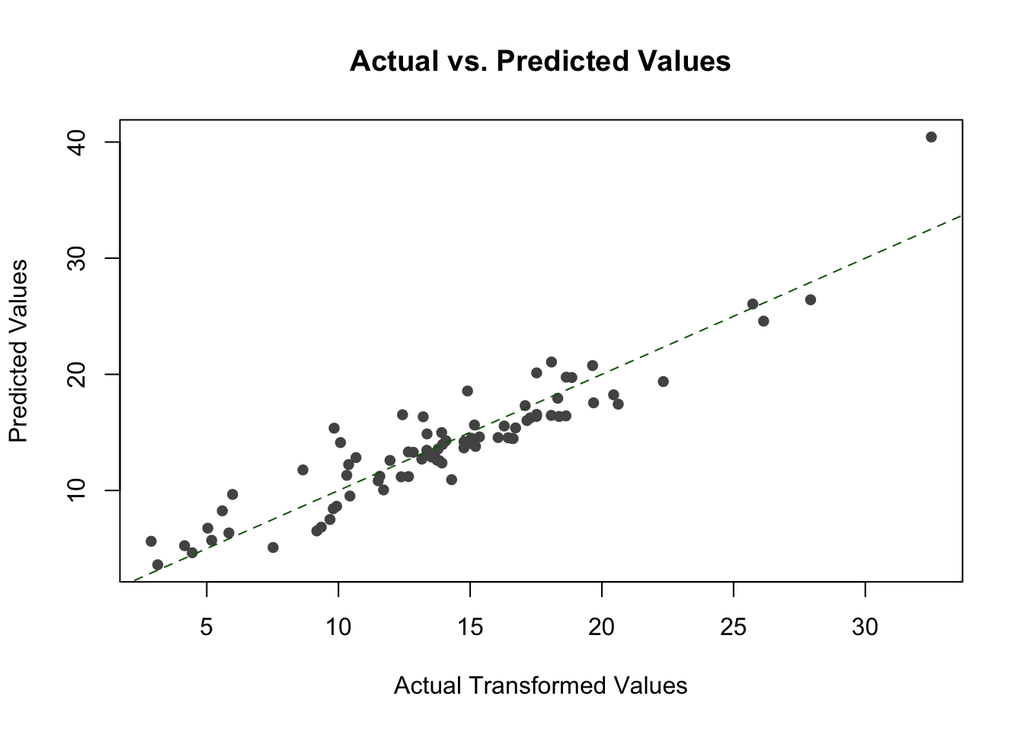

```r
plot(data.test$boxcoxfcover, predict(mod.expts, newdata = data.test),
     col = "grey33", cex = 1.3, pch = 20,
     xlab = "Actual Transformed Values", ylab = "Predicted Values",
     main = "Actual vs. Predicted Values")
# Add a 45-degree reference line for comparison
abline(0, 1, col = "darkgreen", lty = 2)
```

### Regression Diagnostics

This plot is useful for distinguishing between outlier and high leverage points. We make a scatter plot of leverages versus squared Studentized residuals

```r
n <- nrow(train.set.2)
p <- ncol(train.set.2)-1
(hilev <- which(influence(mod.expts)$hat > max(2*(p+1)/n,0.5)))
```

```
## 305 362
## 243 294
```

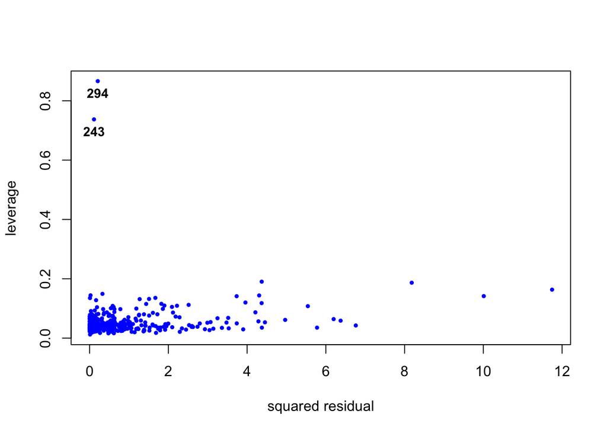

```r
par(mfrow=c(1,1))
plot(rstandard(mod.expts)^2, influence(mod.expts)$hat, pch =19, cex=0.5, col="blue",
     xlab = "squared residual", ylab = "leverage")
inf0 <- which(influence(mod.expts)$hat > 0.5)
text(rstandard(mod.expts)[hilev]^2, influence(mod.expts)$hat[hilev],
     labels = inf0, cex = 0.9, font =2, pos =1)
```

We can observe two data points, 294 and 243 which are leverage points on the X space which indicates those points have high influence on the model and need not to be removed. To calculate the intensity of the influence we can calculate following tests like, DFBEATS, DFFITS, Cook’s Distance.

It’s important to assess the influence of data points in a regression model to identify potential outliers or leverage points. The tests we mentioned above, DFBEATS, DFFITS, and Cook’s Distance, are commonly used to evaluate the influence of individual data points. Here’s a brief explanation of each test:

**DFBEATS (DFFITS-External Studentized Residuals):** DFBEATS measures the impact of removing a single data point from the model by calculating the difference in the fitted values (predicted values) with and without the point in question. If the absolute value of DFBEATS for a data point is significantly larger than 2 divided by the square root of the number of data points, it may indicate that the point has a substantial influence on the model.

**DFFITS (Internal Studentized Residuals):** DFFITS is a measure of how much the predicted values change when a single data point is removed. It helps assess the influence of a data point on the model’s predicted values. Similar to DFBEATS, an absolute value significantly larger than 2 divided by the square root of the number of data points may indicate influence.

**Cook’s Distance:** Cook’s Distance combines the information from DFBEATS and DFFITS and provides a measure of the overall influence of a data point on the entire model. It quantifies how much the regression coefficients change when a data point is removed. A large Cook’s Distance suggests a data point with high influence.

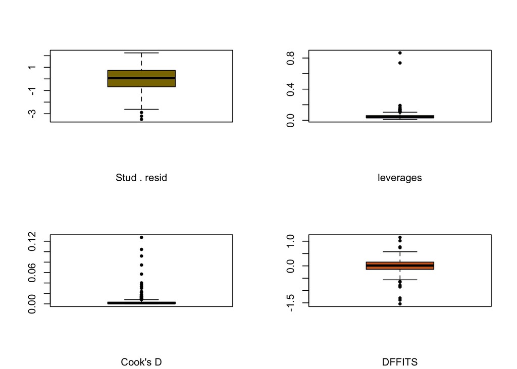

```r
par(mfrow=c(2,2))
boxplot (rstudent (mod.expts), sub =" Stud . resid ", col = "gold4", pch = 20)
boxplot (influence(mod.expts)$hat , sub=" leverages ", col = "burlywood3", pch = 20)
boxplot(cooks.distance(mod.expts), sub = "Cook's D", col = "coral2", pch = 20)
boxplot(dffits(mod.expts), sub = "DFFITS", col = "chocolate3", pch = 20)
```